# Drivers of nutrient concentrations

This notebook relates nutrient concentrations and water quality (PC1, D14) to their drivers: land cover, climate and the weather of the year. The link between these drivers, nutrients and fish (species presence, food web structure) will be the subject of a later notebook.

The notebook starts by getting and presenting the driver data, from their original sources:

- the **catchment** of each station, i.e. the area draining to the station, computed from the [HydroSHEDS](https://www.hydrosheds.org/) flow directions
- the **land cover** of the catchment, from [CORINE Land Cover](https://land.copernicus.eu/en/products/corine-land-cover)
- the **weather** of the catchment, year by year, from [WorldClim](https://worldclim.org/)

and then models the nutrient concentrations on these drivers.

## Setup

```r
library(renv)
renv::load()
library(targets)
library(here)
tar_config_set(
  store = here::here("_targets")
)
library(ggplot2)
library(dplyr)
library(sf)
devtools::load_all()
nice_theme()
```

We study the NAIADES stations having a water quality index (PC1, D14) and fish visits, i.e. the stations whose Sandre code is the site of a fish visit of D12 (target `water_quality_visit`).

```r
station <- tar_read(naiades_station)
water_quality <- tar_read(water_quality)
fish_station <- unique(tar_read(water_quality_visit)$code_station)
district <- tar_read(basin) |>
  filter(district %in% tar_read(params)$district_kept)
direction <- terra::rast(tar_read(flow_direction_file))
station_flow <- tar_read(station_flow) |>
  mutate(
    matched = abs(log(area / rht_area)) < log(1.5),
    studied = code_station %in% water_quality$code_station & code_station %in% fish_station
  )
```

## Catchments

### Flow directions

HydroSHEDS (Lehner et al. 2008) describes where water flows, and it is computed from the elevation of the land only. It does not observe water: it assumes that rain falls everywhere and that water always goes downhill. The idea is illustrated below on a synthetic grid.

1. **Elevation.** The land is cut into a grid of cells (15 arc-seconds, about 450 m × 310 m in France), each with an elevation measured from space.
2. **Flow direction.** From each cell, water goes to the lowest of its 8 neighbours. This gives one arrow per cell, everywhere, whether there is a river or not. This grid of flow direction is the data provided by HydroSHEDS.
3. **Rivers.** Drainage area can be reconstructed from flow directions. Counting for each cell how many cells drain through it (or rather summing their area) gives its upstream area. In other words, a river is simply a cell with a large upstream area: in valley bottoms, the water of a large area passes through.
4. **Catchment.** The catchment of a cell is the set of cells whose arrows eventually lead to it, i.e. the area whose water passes through that cell.

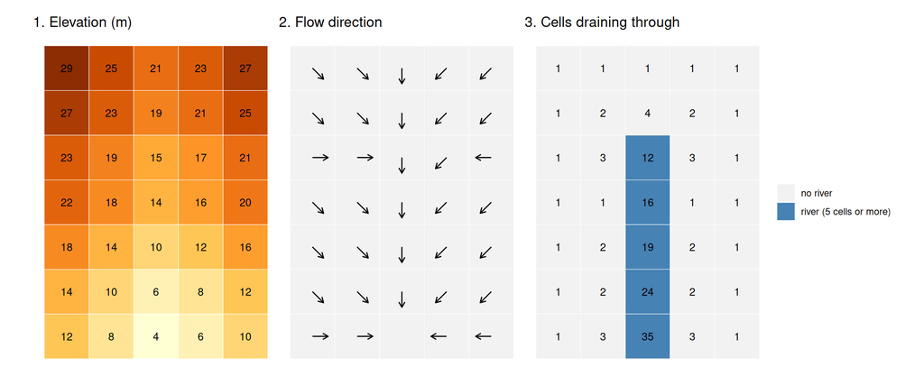

```r
toy <- terra::rast(
  outer(7:1, c(4, 2, 0, 1, 3), \(r, c) 3 * r + 2 * c) + c(0, 1, 0, 2, 1, 0, 1),
  extent = terra::ext(0, 5, 0, 7)
)
toy_direction <- terra::terrain(toy, "flowdir")
toy_angle <- c(`1` = 0, `2` = -45, `4` = -90, `8` = -135, `16` = 180, `32` = 135, `64` = 90, `128` = 45)
toy_df <- as.data.frame(c(toy, toy_direction, terra::flowAccumulation(toy_direction)), xy = TRUE) |>
  setNames(c("x", "y", "elevation", "direction", "cells")) |>
  mutate(
    angle = toy_angle[as.character(direction)] * pi / 180,
    xend = x + 0.35 * cos(angle), yend = y + 0.35 * sin(angle)
  )
patchwork::wrap_plots(
  ggplot(toy_df, aes(x, y)) +
    geom_tile(aes(fill = elevation), colour = "white") +
    geom_text(aes(label = elevation), size = 3.5) +
    scale_fill_distiller(palette = "YlOrBr", direction = 1, guide = "none") +
    coord_equal() +
    theme_void() +
    labs(title = "1. Elevation (m)"),
  ggplot(toy_df, aes(x, y)) +
    geom_tile(fill = "grey95", colour = "white") +
    geom_segment(aes(xend = xend, yend = yend), arrow = arrow(length = unit(2, "mm")), na.rm = TRUE) +
    coord_equal() +
    theme_void() +
    labs(title = "2. Flow direction"),
  ggplot(toy_df, aes(x, y)) +
    geom_tile(aes(fill = cells >= 5), colour = "white") +
    geom_text(aes(label = cells), size = 3.5) +
    scale_fill_manual(
      values = c(`TRUE` = "steelblue", `FALSE` = "grey95"),
      labels = c(`TRUE` = "river (5 cells or more)", `FALSE` = "no river"), name = NULL
    ) +
    coord_equal() +
    theme_void() +
    labs(title = "3. Cells draining through"),
  nrow = 1
)
```

In this made-up valley, the water of the slopes flows to the valley bottom (middle column) and then down to the outlet (bottom, where the water leaves the grid); the cells of the valley bottom collect the water of many cells and form the river. The catchment of the outlet is the whole grid.

The measured elevation has errors, and some structures (bridges, dams, embankments) look like obstacles across the valleys. HydroSHEDS corrects the elevation with existing maps of rivers and lakes, so that the computed rivers follow the real ones.

Summing a value over the catchment of every cell at once is called flow accumulation (`terra::flowAccumulation()`). It gives the upstream area of each cell (left map, only the cells draining more than 50 km²); we will later use the same computation later to average land cover and weather over the catchments.

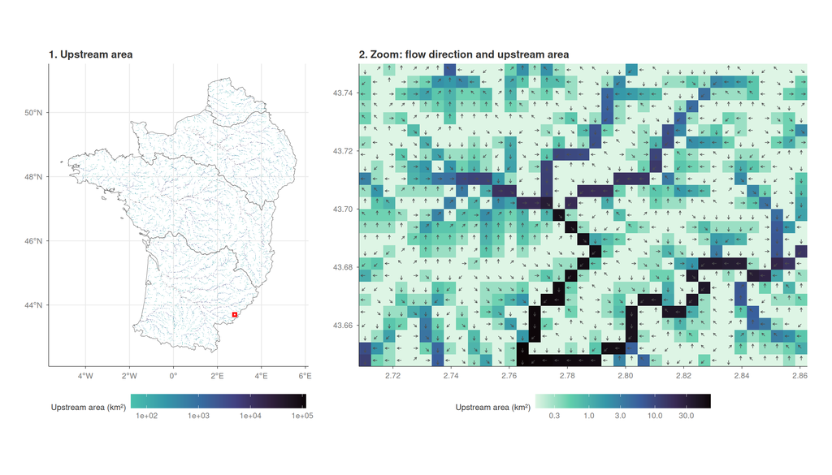

```r
upstream <- terra::flowAccumulation(direction, weight = terra::cellSize(direction, unit = "km"))
upstream_df <- as.data.frame(upstream, xy = TRUE) |>
  setNames(c("x", "y", "area")) |>
  filter(area > 50)
# flow direction and upstream area of the cells of a window, with arrows
flow_arrow <- function(window) {
  window <- terra::align(window, direction, snap = "out")
  angle <- c(`1` = 0, `2` = -45, `4` = -90, `8` = -135, `16` = 180, `32` = 135, `64` = 90, `128` = 45)
  step <- 0.35 * terra::res(direction)[1]
  terra::crop(c(direction, upstream), window) |>
    as.data.frame(xy = TRUE) |>
    setNames(c("x", "y", "code", "area")) |>
    mutate(
      angle = angle[as.character(code)] * pi / 180,
      xend = x + step * cos(angle), yend = y + step * sin(angle)
    )
}
zoom <- terra::ext(2.71, 2.86, 43.65, 43.75)
zoom_df <- flow_arrow(zoom)
patchwork::wrap_plots(
  ggplot() +
    geom_raster(
      aes(x, y, fill = area),
      data = as.data.frame(terra::mask(upstream, terra::vect(district)), xy = TRUE) |>
        setNames(c("x", "y", "area")) |>
        filter(area > 50)
    ) +
    geom_sf(data = district, fill = NA, colour = "grey40") +
    annotate(
      "rect", xmin = zoom$xmin, xmax = zoom$xmax, ymin = zoom$ymin, ymax = zoom$ymax,
      fill = NA, colour = "red", linewidth = 1
    ) +
    scale_fill_viridis_c(trans = "log10", option = "mako", direction = -1, end = 0.75, name = "Upstream area (km²)") +
    labs(x = NULL, y = NULL, title = "1. Upstream area") +
    theme(legend.position = "bottom", legend.key.width = unit(1.5, "cm")),
  ggplot(zoom_df) +
    geom_raster(aes(x, y, fill = area)) +
    geom_segment(
      aes(x, y, xend = xend, yend = yend), colour = "grey30", linewidth = 0.3,
      arrow = arrow(length = unit(1, "mm")), na.rm = TRUE
    ) +
    scale_fill_viridis_c(trans = "log10", option = "mako", direction = -1, name = "Upstream area (km²)") +
    coord_sf(expand = FALSE) +
    labs(x = NULL, y = NULL, title = "2. Zoom: flow direction and upstream area") +
    theme(legend.position = "bottom", legend.key.width = unit(1.5, "cm")),
  nrow = 1
)
```

The next step is to snap our stations to this flow lines, so we can get their catchment area.

### Snapping stations

The HydroSHEDS grid is relatively coarse. So it happens that the river often passes one or two cells away from the station. Then, we move each station to the cell, within 1 km, whose upstream area is closest to the drained area of the nearest reach of the RHT (Pella et al. (2012)). Stations whose upstream area is still more than 1.5 times larger or smaller than the RHT area (outside the blue band below) are considered unmatched (target `station_flow`).

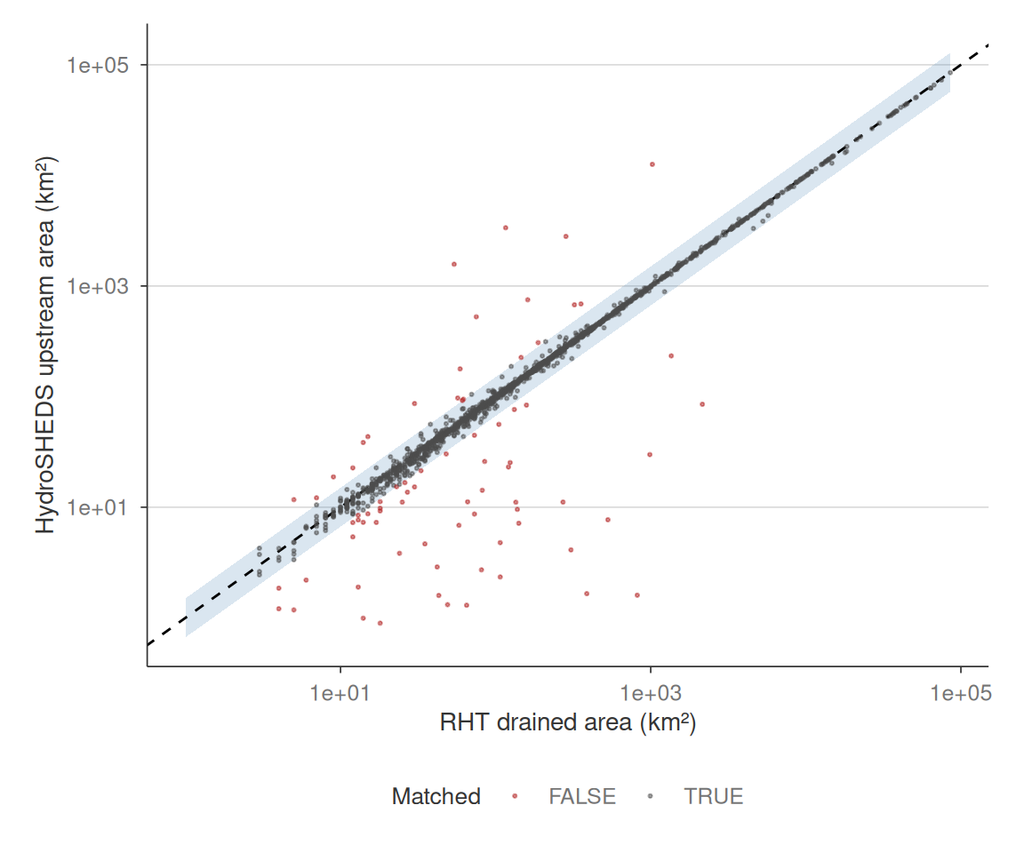

```r
station_flow |>
  filter(studied) |>
  ggplot(aes(rht_area, area, colour = matched)) +
  geom_ribbon(
    aes(x, ymin = x / 1.5, ymax = x * 1.5),
    data = tibble(x = 10^seq(0, log10(max(station_flow$rht_area[station_flow$studied])), length.out = 100)),
    inherit.aes = FALSE, fill = "steelblue", alpha = 0.2
  ) +
  geom_abline(linetype = "dashed") +
  geom_point(size = 0.4, alpha = 0.5) +
  scale_x_log10() +
  scale_y_log10() +
  scale_colour_manual(values = c(`TRUE` = "grey30", `FALSE` = "firebrick"), name = "Matched") +
  labs(x = "RHT drained area (km²)", y = "HydroSHEDS upstream area (km²)")
```

```r
station_flow |>
  filter(studied) |>
  summarise(
    stations = n(), matched = sum(matched), `matched (%)` = round(100 * sum(matched) / n()),
    `median area (km²)` = median(area[matched])
  ) |>
  knitr::kable()
```

[output not shown]

Most stations are snapped correctly, we only leave out 5% of the stations which we consider to be satisfying.

Now that we have our stations snapped to the HydroSHEDS flow cells we can compute their catchment. We illustrate this below.

### Example catchments

The catchment of a station is drawn by following the flow directions upstream (`terra::watershed()`). To illustrate, we plot three stations and their catchment with different draining area below.

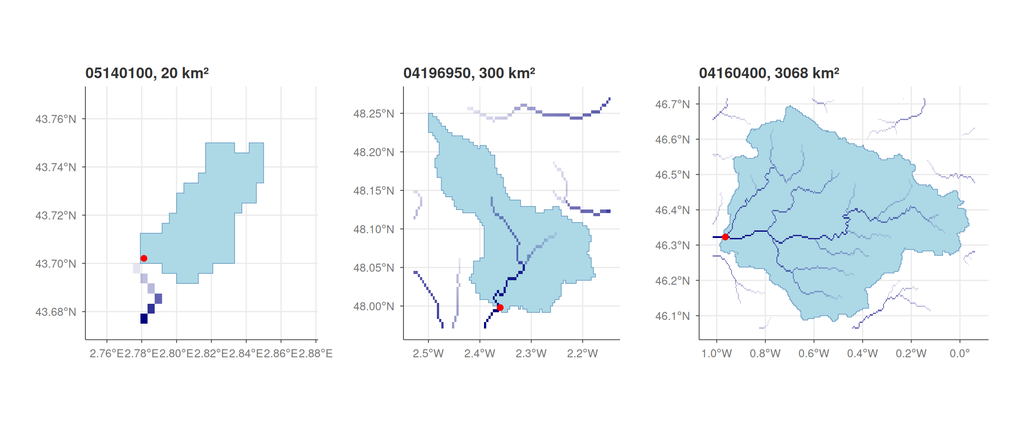

```r
example <- purrr::map_dfr(c(20, 300, 3000), \(size) {
  station_flow |>
    filter(matched, studied) |>
    slice_min(abs(log(area / size)), n = 1, with_ties = FALSE)
})
draw_catchment <- function(example) {
  watershed <- terra::watershed(direction, pourpoint = cbind(example$longitude, example$latitude))
  terra::as.polygons(terra::ifel(watershed == 1, 1, NA)) |>
    st_as_sf() |>
    mutate(code_station = example$code_station, area = example$area)
}
catchment <- purrr::map_dfr(seq_len(nrow(example)), \(i) draw_catchment(example[i, ]))
plot_catchment <- function(i) {
  frame <- st_bbox(st_buffer(catchment[i, ], 2000))
  stream <- upstream_df |>
    filter(between(x, frame["xmin"], frame["xmax"]), between(y, frame["ymin"], frame["ymax"]))
  plot <- ggplot() +
    geom_sf(data = catchment[i, ], fill = "lightblue", colour = "steelblue") +
    geom_raster(aes(x, y, alpha = log10(area)), data = stream, fill = "navy", show.legend = FALSE) +
    geom_point(aes(longitude, latitude), data = example[i, ], colour = "red", size = 2) +
    coord_sf(xlim = frame[c("xmin", "xmax")], ylim = frame[c("ymin", "ymax")]) +
    labs(x = NULL, y = NULL, title = sprintf("%s, %.0f km²", example$code_station[i], example$area[i]))
}
patchwork::wrap_plots(lapply(seq_len(nrow(example)), plot_catchment), nrow = 1)
```

These catchments are useful because from them we can get the land use or climate that is affecting any given stations. We derive this environmental information in what follows.

## Land cover

### CORINE Land Cover

CORINE Land Cover maps land cover using satellite images (Landsat). A mapping unit is a polygon of at least 25 ha. A vintage is one edition of the map, for a reference year: we use the 2000, 2006, 2012 and 2018 vintages for mainland France. Each vintage also comes with a layer of the changes since the previous vintage, mapped with a finer unit of 5 ha.

Next, we dive into the nomenclature of the database which is used to classify the different land-uses.

#### Nomenclature

There are 3 different levels of classifications, from finer to coarser

- level 3 has 44 classes;
- level 2 has 15 classes;
- level 1 has 5 classes.

For sake of simplicity, we present the data at level 1, which is enough to describe the landscape. For the models, we split the agricultural areas into **arable land** (level 2 class 21) and **other farmland** (classes 22-24: permanent pastures, vineyards and orchards), since they act differently on nitrate.

These five groups are used for the catchments:

```r
corine_class <- tibble::tribble(
  ~class, ~name, ~group, ~colour,
  11, "Urban fabric", "Artificial", "#e6004d",
  12, "Industrial, commercial and transport units", "Artificial", "#cc4df2",
  13, "Mine, dump and construction sites", "Artificial", "#a600cc",
  14, "Artificial, non-agricultural vegetated areas", "Artificial", "#ffa6ff",
  21, "Arable land", "Agricultural", "#ffffa8",
  22, "Permanent crops (vineyards, orchards)", "Agricultural", "#e68000",
  23, "Pastures", "Agricultural", "#e6e64d",
  24, "Heterogeneous agricultural areas", "Agricultural", "#ffe6a6",
  31, "Forests", "Forest and semi-natural", "#00a600",
  32, "Scrub and herbaceous vegetation", "Forest and semi-natural", "#a6f200",
  33, "Open spaces with little or no vegetation", "Forest and semi-natural", "#e6e6e6",
  41, "Inland wetlands", "Wetlands", "#a6a6ff",
  42, "Maritime wetlands", "Wetlands", "#ccccff",
  51, "Inland waters", "Water bodies", "#80f2e6",
  52, "Marine waters", "Water bodies", "#e6f2ff"
) |>
  mutate(category = case_when(
    group == "Agricultural" & class == 21 ~ "Arable land",
    group == "Agricultural" ~ "Other farmland",
    group %in% c("Wetlands", "Water bodies") ~ "Wetlands and water",
    .default = group
  ))
corine_colour <- setNames(corine_class$colour, corine_class$name)
group_colour <- c(
  "Artificial" = "#e6004d", "Agricultural" = "#ffd84d", "Forest and semi-natural" = "#2e8b3a",
  "Wetlands" = "#a6a6ff", "Water bodies" = "#4da6ff"
)
category_colour <- c(
  "Artificial" = "#e6004d", "Arable land" = "#ffd84d", "Other farmland" = "#b8c95b",
  "Forest and semi-natural" = "#2e8b3a", "Wetlands and water" = "#4da6ff"
)
corine_code <- tibble::tribble(
  ~code, ~code_name,
  111, "Continuous urban fabric", 112, "Discontinuous urban fabric",
  121, "Industrial or commercial units", 122, "Road and rail networks", 123, "Port areas",
  124, "Airports", 131, "Mineral extraction sites", 132, "Dump sites", 133, "Construction sites",
  141, "Green urban areas", 142, "Sport and leisure facilities",
  211, "Non-irrigated arable land", 212, "Permanently irrigated land", 213, "Rice fields",
  221, "Vineyards", 222, "Fruit trees and berry plantations", 223, "Olive groves",
  231, "Pastures", 241, "Annual crops associated with permanent crops",
  242, "Complex cultivation patterns",
  243, "Agriculture with significant areas of natural vegetation", 244, "Agro-forestry areas",
  311, "Broad-leaved forest", 312, "Coniferous forest", 313, "Mixed forest",
  321, "Natural grasslands", 322, "Moors and heathland", 323, "Sclerophyllous vegetation",
  324, "Transitional woodland-shrub", 331, "Beaches, dunes, sands", 332, "Bare rocks",
  333, "Sparsely vegetated areas", 334, "Burnt areas", 335, "Glaciers and perpetual snow",
  411, "Inland marshes", 412, "Peat bogs", 421, "Salt marshes", 422, "Salines",
  423, "Intertidal flats", 511, "Water courses", 512, "Water bodies", 521, "Coastal lagoons",
  522, "Estuaries", 523, "Sea and ocean"
) |>
  mutate(class = code %/% 10)
knitr::kable(
  select(corine_class, group, class, name, category),
  col.names = c("Level 1", "Code", "Level 2", "Group used for the catchments")
)
```

| Level 1 | Code | Level 2 | Group used for the catchments |
| --- | --- | --- | --- |
| Artificial | 11 | Urban fabric | Artificial |
| Artificial | 12 | Industrial, commercial and transport units | Artificial |
| Artificial | 13 | Mine, dump and construction sites | Artificial |
| Artificial | 14 | Artificial, non-agricultural vegetated areas | Artificial |
| Agricultural | 21 | Arable land | Arable land |
| Agricultural | 22 | Permanent crops (vineyards, orchards) | Other farmland |
| Agricultural | 23 | Pastures | Other farmland |
| Agricultural | 24 | Heterogeneous agricultural areas | Other farmland |
| Forest and semi-natural | 31 | Forests | Forest and semi-natural |
| Forest and semi-natural | 32 | Scrub and herbaceous vegetation | Forest and semi-natural |
| Forest and semi-natural | 33 | Open spaces with little or no vegetation | Forest and semi-natural |
| Wetlands | 41 | Inland wetlands | Wetlands and water |
| Wetlands | 42 | Maritime wetlands | Wetlands and water |
| Water bodies | 51 | Inland waters | Wetlands and water |
| Water bodies | 52 | Marine waters | Wetlands and water |

Next, we look at the spatial unit used in the database, that is the polygons.

#### Polygons

Number and size of the polygons of each vintage (sea excluded):

```r
corine_polygon <- tar_read(corine_polygon) |>
  filter(code != 523)
corine_polygon |>
  summarise(
    polygons = n(), `median area (ha)` = median(area),
    `polygons < 25 ha (%)` = 100 * mean(area < 24.5),
    `total area (km²)` = sum(area) / 100,
    .by = year
  ) |>
  knitr::kable(digits = 1, format.args = list(big.mark = ","))
```

| year | polygons | median area (ha) | polygons < 25 ha (%) | total area (km²) |
| --- | --- | --- | --- | --- |
| 2,000 | 270,461 | 57.0 | 0.1 | 563,576.3 |
| 2,006 | 273,061 | 56.4 | 0.1 | 563,354.7 |
| 2,012 | 274,569 | 56.2 | 0.4 | 554,670.0 |
| 2,018 | 275,376 | 56.1 | 0.5 | 556,959.1 |

And the distribution of polygon areas.

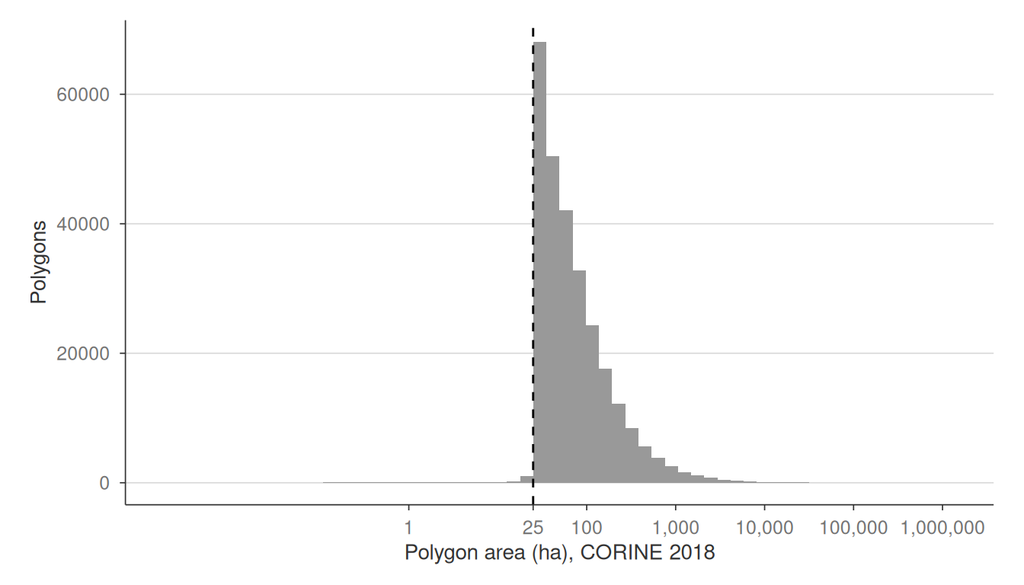

```r
corine_polygon |>
  filter(year == 2018) |>
  ggplot(aes(area)) +
  geom_histogram(bins = 60, fill = "grey60") +
  geom_vline(xintercept = 25, linetype = "dashed") +
  scale_x_log10(breaks = c(1, 25, 100, 1000, 1e4, 1e5, 1e6), labels = scales::label_comma(accuracy = 1)) +
  labs(x = "Polygon area (ha), CORINE 2018", y = "Polygons")
```

The few polygons under 25 ha are cut by the national border or the coast. The largest ones are forests and mountain areas of thousands of hectares.

Now that we have investigate the polygon we can have a look at the map.

#### Map

Here is the map of land-uses (level 1 classes, for 2018).

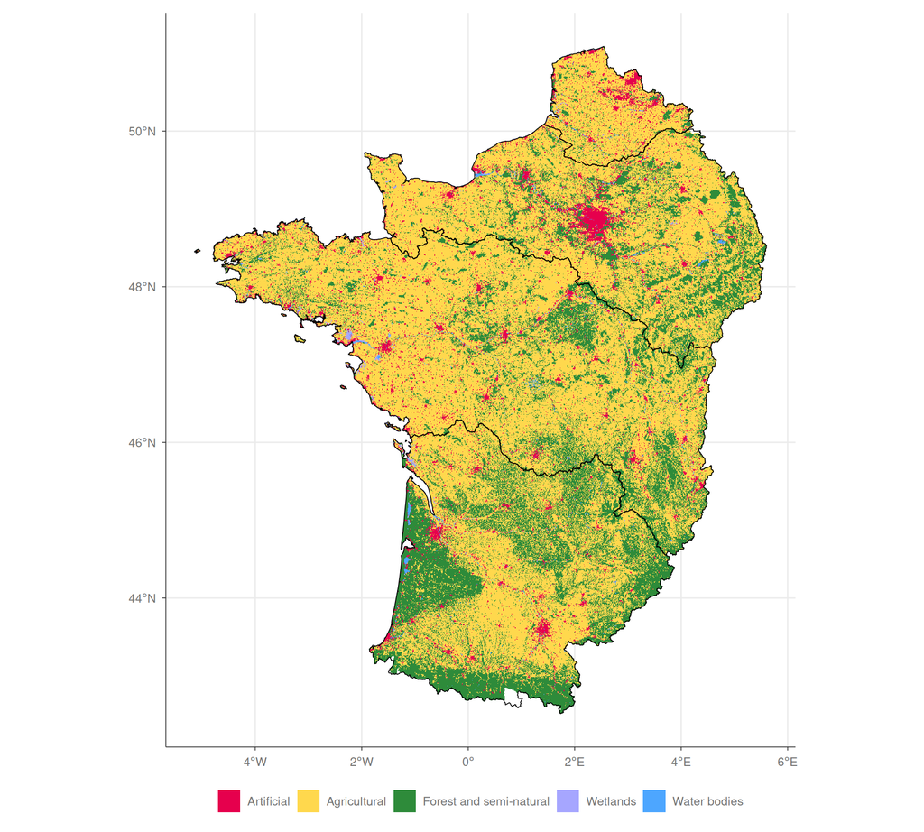

```r
corine_map <- terra::rast(tar_read(corine_map_file))
corine_map <- terra::mask(terra::crop(corine_map, terra::vect(district)), terra::vect(district))
as.data.frame(corine_map, xy = TRUE) |>
  setNames(c("x", "y", "code")) |>
  filter(!is.na(code), code > 0, code != 523) |>
  mutate(class = code %/% 10) |>
  left_join(corine_class, by = "class") |>
  mutate(group = factor(group, names(group_colour))) |>
  ggplot() +
  geom_raster(aes(x, y, fill = group)) +
  geom_sf(data = district, fill = NA, colour = "black", linewidth = 0.3) +
  scale_fill_manual(values = group_colour, name = NULL) +
  labs(x = NULL, y = NULL) +
  theme(legend.position = "bottom")
```

Agricultural areas cover most of the four districts. Forests and semi-natural areas form large blocks, and artificial areas are small spots except Paris.

We can also plot the share of the different classes across the years.

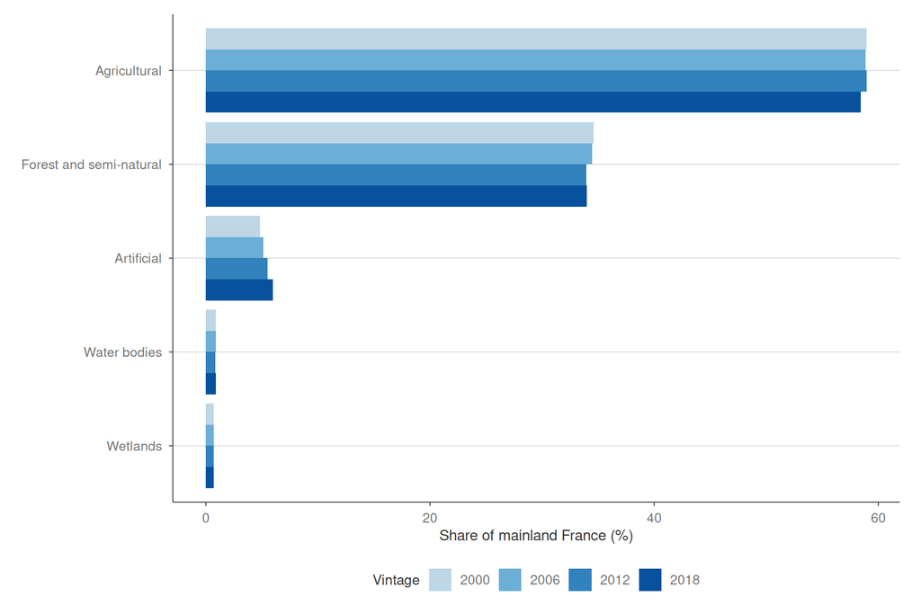

```r
corine_area <- corine_polygon |>
  mutate(class = code %/% 10) |>
  summarise(area = sum(area), .by = c(year, class)) |>
  mutate(share = 100 * area / sum(area), .by = year) |>
  left_join(corine_class, by = "class")
corine_area |>
  summarise(share = sum(share), .by = c(year, group)) |>
  mutate(group = forcats::fct_reorder(group, share, mean)) |>
  ggplot(aes(share, group, fill = factor(year))) +
  geom_col(position = position_dodge(reverse = TRUE)) +
  scale_fill_manual(values = RColorBrewer::brewer.pal(5, "Blues")[-1], name = "Vintage") +
  labs(x = "Share of mainland France (%)", y = NULL)
```

Agricultural land dominates land uses. Overall, the share of land-uses doesn’t change much over the years. We mainly notice an increase of artificial areas.

### Land cover of the catchments

For each vintage, we rasterise the CORINE polygons (level-2 classes) on the flow-direction grid, such that for each cell we have the fraction of covered by the class. The share of a class in the catchment of a station is the flow accumulation of the class area divided by the total flow accumulation.

We illustrate this with an example below.

```r
landcover <- tar_read(station_landcover) |>
  semi_join(filter(station_flow, matched, studied), by = "code_station") |>
  left_join(corine_class, by = "class")
```

We perform the following steps:

1. we keep the polygons intersecting the catchment;
2. the polygons are rasterised on a grid 5 times finer than the flow-direction grid, and the fraction of each flow cell covered by each land cover class is computed;
3. the share of each class in the catchment is the mean of these fractions over the cells of the catchment, weighted by cell area. Flow accumulation computes this mean for all the cells of the grid at once.

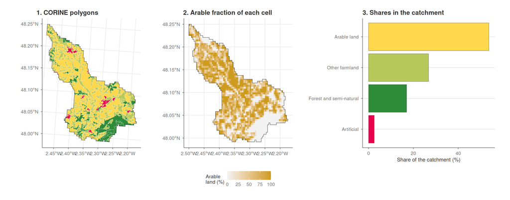

```r
corine_zip <- tar_read(corine_zip)
example_station <- example[2, ]
example_catchment <- catchment[2, ]
example_window <- terra::align(terra::ext(terra::vect(st_buffer(example_catchment, 2000))), direction, snap = "out")
example_watershed <- terra::crop(
  terra::watershed(direction, pourpoint = cbind(example_station$longitude, example_station$latitude)),
  example_window
)
# 1. polygons cut along the catchment
example_polygon <- read_corine(corine_zip[grepl("2018", corine_zip)], example_catchment) |>
  st_intersection(st_transform(st_geometry(example_catchment), 2154)) |>
  mutate(class = code %/% 10) |>
  left_join(corine_class, by = "class")
# 2. fraction of arable land in each flow-direction cell
example_fine <- rasterize_corine(
  corine_zip[grepl("2018", corine_zip)], as.vector(example_window), terra::res(direction)[1] / 5,
  tempfile(fileext = ".tif")
)
example_cover <- terra::aggregate(terra::rast(example_fine) %/% 10 == 21, 5, mean)
example_cell <- c(example_cover, example_watershed) |>
  as.data.frame(xy = TRUE) |>
  setNames(c("x", "y", "arable", "inside")) |>
  filter(inside == 1)
# 3. shares in the catchment
example_share <- landcover |>
  filter(code_station == example_station$code_station, year == 2018) |>
  summarise(share = sum(share), .by = category) |>
  filter(share > 0)
patchwork::wrap_plots(
  ggplot() +
    geom_sf(aes(fill = category), data = example_polygon, colour = "white", linewidth = 0.1, show.legend = FALSE) +
    geom_sf(data = example_catchment, fill = NA, colour = "black") +
    scale_fill_manual(values = category_colour) +
    labs(title = "1. CORINE polygons"),
  ggplot() +
    geom_tile(aes(x, y, fill = 100 * arable), data = example_cell) +
    geom_sf(data = example_catchment, fill = NA, colour = "black") +
    scale_fill_gradient(low = "grey95", high = "goldenrod3", name = "Arable\nland (%)") +
    labs(x = NULL, y = NULL, title = "2. Arable fraction of each cell"),
  example_share |>
    mutate(category = forcats::fct_reorder(category, share, max)) |>
    ggplot(aes(share, category, fill = category)) +
    geom_col(colour = "grey30", linewidth = 0.2, show.legend = FALSE) +
    scale_fill_manual(values = category_colour) +
    labs(x = "Share of the catchment (%)", y = NULL, title = "3. Shares in the catchment"),
  nrow = 1, widths = c(1, 1, 1.2)
)
```

We can do this for all station catchments to have an overview of the data.

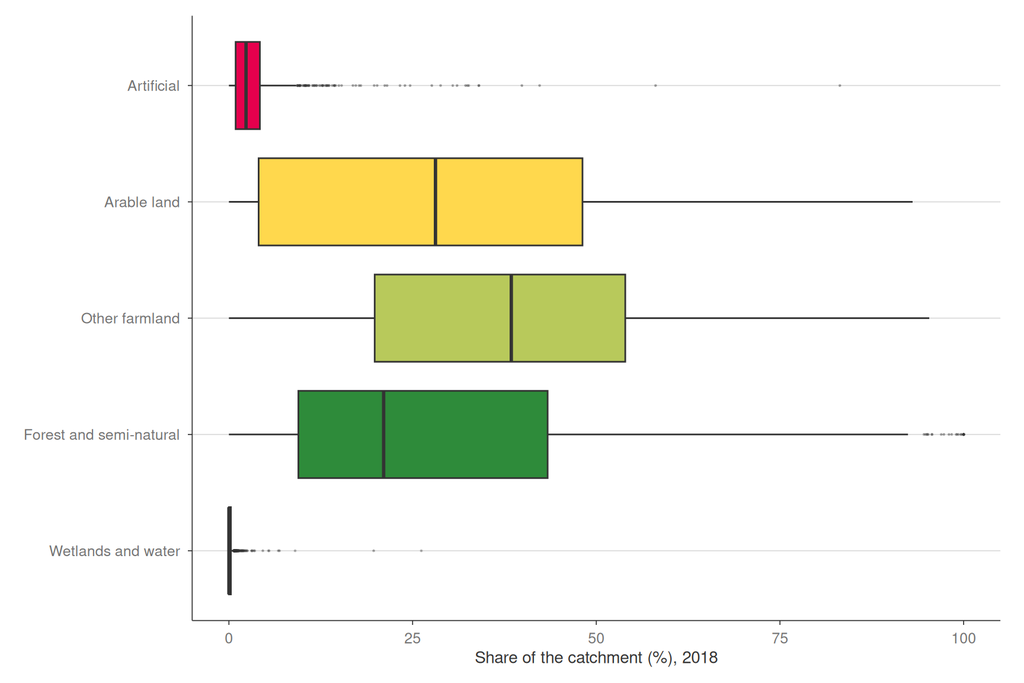

```r
landcover |>
  filter(year == 2018) |>
  summarise(share = sum(share), .by = c(code_station, category)) |>
  mutate(category = factor(category, rev(names(category_colour)))) |>
  ggplot(aes(share, category, fill = category)) +
  geom_boxplot(outlier.size = 0.2, outlier.alpha = 0.3, show.legend = FALSE) +
  scale_fill_manual(values = category_colour) +
  labs(x = "Share of the catchment (%), 2018", y = NULL)
```

We retrieve that farmland and arable dominates, followed by natural and artificial areas.

Next, we have a look at the weather data from WorldClim.

## Weather

### WorldClim

WorldClim historical monthly weather gives, for each month from 1950 to 2021, the precipitation and the means of the daily minimum and maximum temperature, on a 2.5 arc-minute grid (about 4.5 km). Each monthly value combines two sources:

- a **baseline**, constant in time: the WorldClim 1970-2000 average of the calendar month (Fick and Hijmans 2017), interpolated at fine resolution from many weather stations, elevation and satellite data. It carries the spatial detail (relief, rain shadows);
- a **departure** from this baseline: how much the month differs from its 1970-2000 average in CRU TS (Harris et al. 2020), a coarser interpolation of weather stations on a 0.5° grid (about 50 km). It carries the variation between years, and is added to the baseline for temperature and multiplied with it for precipitation.

So the differences between places are well resolved, but the year-to-year variation is smooth over about 50 km: nearby catchments get almost the same weather anomaly in a given year. We keep 2000-2021 (target `worldclim_file`) and summarise each year by the annual precipitation, the annual mean temperature and the summer (June-August) mean of the daily maximum temperature.

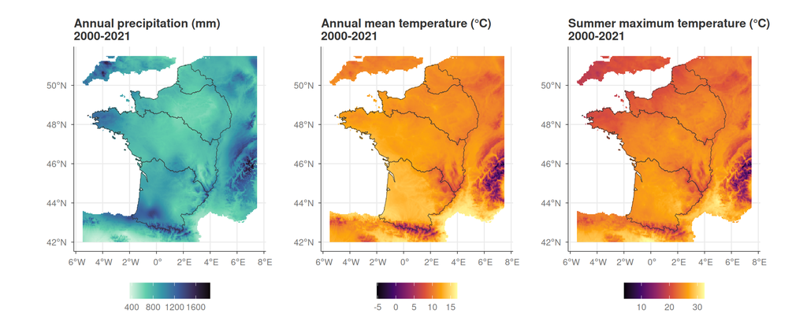

```r
yearly <- summarise_worldclim(tar_read(worldclim_file))
weather_mean <- c(
  terra::mean(yearly[[grepl("^precipitation", names(yearly))]]),
  terra::mean(yearly[[grepl("^temperature", names(yearly))]]),
  terra::mean(yearly[[grepl("^summer_tmax", names(yearly))]])
)
names(weather_mean) <- c("Annual precipitation (mm)", "Annual mean temperature (°C)", "Summer maximum temperature (°C)")
patchwork::wrap_plots(lapply(names(weather_mean), \(v) {
  ggplot() +
    geom_raster(aes(x, y, fill = value), data = setNames(as.data.frame(weather_mean[[v]], xy = TRUE), c("x", "y", "value"))) +
    geom_sf(data = district, fill = NA, colour = "grey20") +
    scale_fill_viridis_c(option = if (grepl("precipitation", v)) "mako" else "inferno", direction = if (grepl("precipitation", v)) -1 else 1, name = NULL) +
    labs(x = NULL, y = NULL, title = paste(v, "\n2000-2021"))
}), nrow = 1)
```

Next, we compute the climate information for each catchment-year.

### Weather of the catchments

We proceed as for land cover.

The WorldClim cells are split into the cells of the flow-direction grid (10 × 10 per WorldClim cell), and the weather of a catchment in a year is the mean over the catchment, weighted by cell area (target `station_weather`).

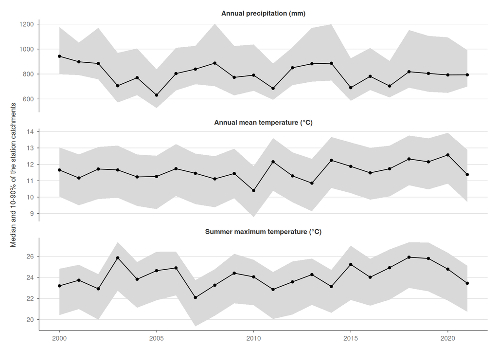

```r
weather <- tar_read(station_weather) |>
  semi_join(filter(station_flow, matched, studied), by = "code_station")
weather |>
  tidyr::pivot_longer(c(precipitation, temperature, summer_tmax)) |>
  summarise(
    low = quantile(value, 0.1), median = median(value), high = quantile(value, 0.9),
    .by = c(name, year)
  ) |>
  mutate(name = factor(name, c("precipitation", "temperature", "summer_tmax"), c("Annual precipitation (mm)", "Annual mean temperature (°C)", "Summer maximum temperature (°C)"))) |>
  ggplot(aes(year, median)) +
  geom_ribbon(aes(ymin = low, ymax = high), fill = "grey85") +
  geom_line() +
  geom_point() +
  facet_wrap(~name, ncol = 1, scales = "free_y") +
  labs(x = NULL, y = "Median and 10-90% of the station catchments")
```

We can illustrate this with an example.

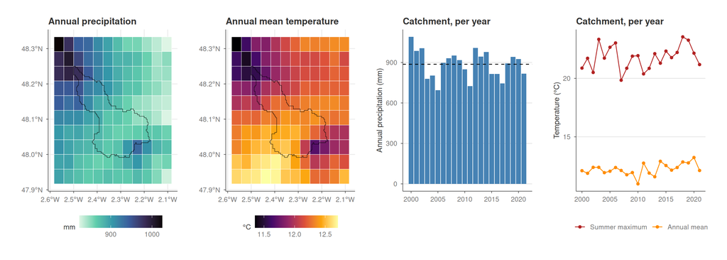

```r
example_frame <- terra::ext(terra::vect(st_buffer(example_catchment, 5000)))
example_weather_map <- terra::crop(weather_mean[[1:2]], example_frame, snap = "out") |>
  as.data.frame(xy = TRUE) |>
  setNames(c("x", "y", "precipitation", "temperature"))
example_year <- tar_read(station_weather) |>
  filter(code_station == example_station$code_station)
patchwork::wrap_plots(
  ggplot() +
    geom_tile(aes(x, y, fill = precipitation), data = example_weather_map, colour = "white", linewidth = 0.2) +
    geom_sf(data = example_catchment, fill = NA, colour = "black") +
    scale_fill_viridis_c(option = "mako", direction = -1, name = "mm", n.breaks = 4, guide = guide_colourbar(barwidth = 8)) +
    labs(x = NULL, y = NULL, title = "Annual precipitation"),
  ggplot() +
    geom_tile(aes(x, y, fill = temperature), data = example_weather_map, colour = "white", linewidth = 0.2) +
    geom_sf(data = example_catchment, fill = NA, colour = "black") +
    scale_fill_viridis_c(option = "inferno", name = "°C", n.breaks = 4, guide = guide_colourbar(barwidth = 8)) +
    labs(x = NULL, y = NULL, title = "Annual mean temperature"),
  ggplot(example_year, aes(year, precipitation)) +
    geom_col(fill = "steelblue") +
    geom_hline(yintercept = mean(example_year$precipitation), linetype = "dashed") +
    labs(x = NULL, y = "Annual precipitation (mm)", title = "Catchment, per year"),
  ggplot(tidyr::pivot_longer(example_year, c(temperature, summer_tmax)), aes(year, value, colour = name)) +
    geom_line() +
    geom_point() +
    scale_colour_manual(
      values = c(temperature = "darkorange", summer_tmax = "firebrick"),
      labels = c(temperature = "Annual mean", summer_tmax = "Summer maximum"), name = NULL
    ) +
    labs(x = NULL, y = "Temperature (°C)", title = "Catchment, per year") +
    theme(legend.position = "bottom"),
  nrow = 1
)
```

We are ready to model the drivers effect on nutrients.

## Drivers of nutrients

Correlation between the catchment drivers across stations (2018 land cover, mean weather 2000-2021, catchment area):

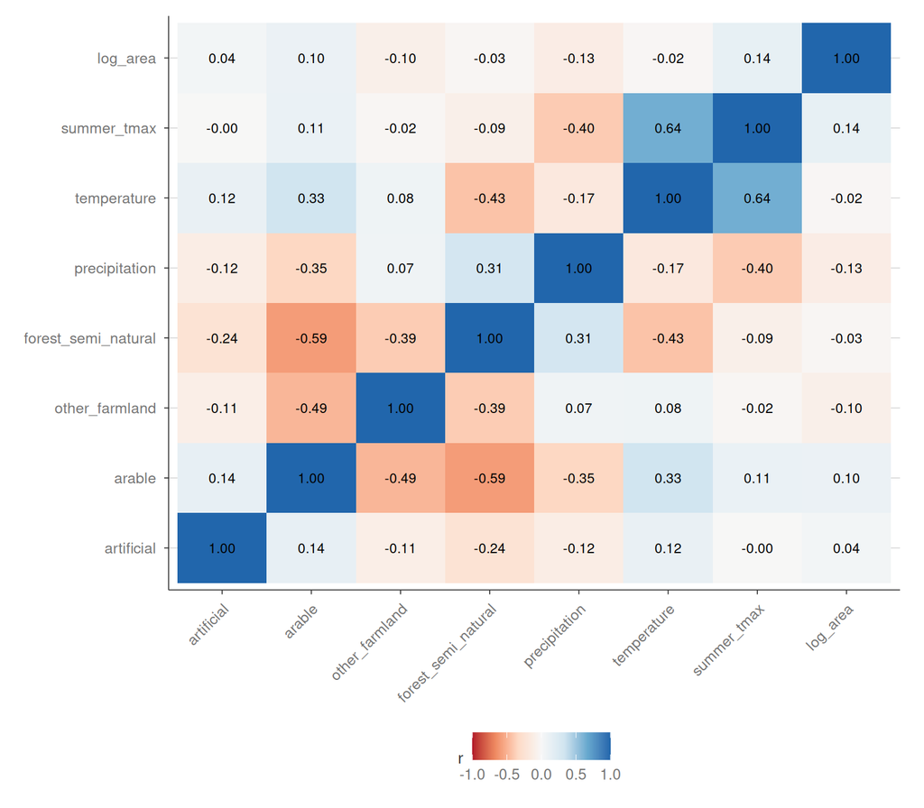

```r
driver <- landcover |>
  filter(year == 2018) |>
  filter(category != "Wetlands and water") |>
  mutate(type = c(
    "Artificial" = "artificial", "Arable land" = "arable", "Other farmland" = "other_farmland",
    "Forest and semi-natural" = "forest_semi_natural"
  )[category]) |>
  summarise(share = sum(share), .by = c(code_station, type)) |>
  tidyr::pivot_wider(names_from = type, values_from = share) |>
  inner_join(
    weather |> summarise(across(c(precipitation, temperature, summer_tmax), mean), .by = code_station),
    by = "code_station"
  ) |>
  inner_join(transmute(station_flow, code_station, log_area = log10(area)), by = "code_station")
correlation <- cor(select(driver, -code_station))
as.data.frame(as.table(correlation)) |>
  ggplot(aes(Var1, Var2, fill = Freq)) +
  geom_tile() +
  geom_text(aes(label = sprintf("%.2f", Freq)), size = 3) +
  scale_fill_distiller(palette = "RdBu", limits = c(-1, 1), direction = 1, name = "r") +
  labs(x = NULL, y = NULL) +
  theme(axis.text.x = element_text(angle = 45, hjust = 1))
```

We can start to build the model.

### Model

For each nutrient (log10 station-year mean, see D14) and for the water quality index PC1, we build a Gaussian model of the standardised response on the following drivers, all standardised:

- land cover
- climate (mean over 2000-2021)
- weather of the year (anomaly compared to the mean)
- catchment area (for control)

We also add a spatial field (SPDE), an AR1 year effect shared by all stations (national dry or wet years, trends) and an iid station effect.

```r
driver_data <- tar_read(driver_data)
driver_model <- tar_read(driver_model)
tibble(
  `station-years` = nrow(driver_data),
  stations = n_distinct(driver_data$code_station),
  years = paste(range(driver_data$year), collapse = "-")
) |>
  knitr::kable(format.args = list(big.mark = ","))
```

| station-years | stations | years |
| --- | --- | --- |
| 19,871 | 1,406 | 2001-2021 |

Next, we run the model and plot the results as a coefplot.

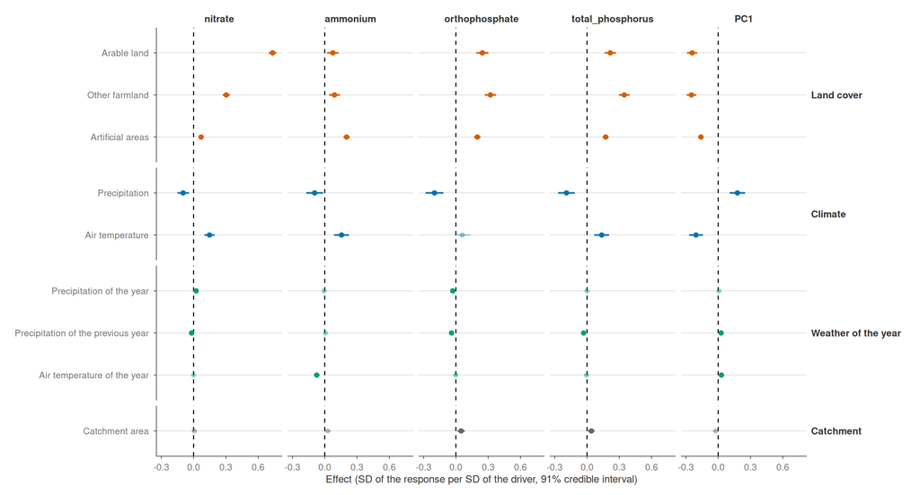

```r
driver_label <- c(
  arable = "Arable land", other_farmland = "Other farmland", artificial = "Artificial areas", precipitation = "Precipitation", air_temperature = "Air temperature",
  area = "Catchment area",
  precipitation_anomaly = "Precipitation of the year", precipitation_previous = "Precipitation of the previous year",
  temperature_anomaly = "Air temperature of the year"
)
driver_group <- c(
  arable = "Land cover", other_farmland = "Land cover", artificial = "Land cover",
  precipitation = "Climate", air_temperature = "Climate", area = "Catchment",
  precipitation_anomaly = "Weather of the year", precipitation_previous = "Weather of the year",
  temperature_anomaly = "Weather of the year"
)
driver_colour <- c(
  "Land cover" = "#D55E00", "Climate" = "#0072B2", "Weather of the year" = "#009E73", "Catchment" = "grey40"
)
driver_effect <- purrr::map_dfr(driver_model, \(m) {
  tibble::as_tibble(m$summary.fixed, rownames = "term") |>
    filter(term != "Intercept") |>
    transmute(response = m$response, term, mean, low = `0.045quant`, high = `0.955quant`)
}) |>
  mutate(
    credible = sign(low) == sign(high),
    group = factor(driver_group[term], c("Land cover", "Climate", "Weather of the year", "Catchment")),
    term = factor(driver_label[term], rev(driver_label)),
    response = factor(response, c("nitrate", "ammonium", "orthophosphate", "total_phosphorus", "PC1"))
  )
ggplot(driver_effect, aes(mean, term, colour = group, alpha = credible)) +
  geom_vline(xintercept = 0, linetype = "dashed") +
  geom_pointrange(aes(xmin = low, xmax = high), size = 0.3, linewidth = 0.8) +
  scale_colour_manual(values = driver_colour, guide = "none") +
  scale_alpha_manual(values = c(`TRUE` = 1, `FALSE` = 0.3), guide = "none") +
  facet_grid(group ~ response, scales = "free_y", space = "free_y") +
  labs(x = "Effect (SD of the response per SD of the driver, 91% credible interval)", y = NULL) +
  theme(strip.text.y = element_text(angle = 0, hjust = 0))
```

**Results:**

- **Land cover** is by far the strongest driver. Arable land is the main source of nitrate, raising it much more than other farmland. Phosphorus rises as much with other farmland as with arable land, and also with artificial areas, which are the main source of ammonium. Water quality (PC1) decreases with all three.
- **Climate:** drier catchments have more nutrients, especially phosphorus, and warmer catchments too; both have a lower water quality.
- **Weather of the year** has small effects compared with land cover and climate. Nutrients are slightly higher after a dry year (the flush of what accumulated during the dry year), and ammonium is lower in warm years.
- **Catchment area** has almost no effect.

## Next steps

- The link with fish (species presence, food web structure) will be studied in a separate notebook, with a model of the paths from the drivers to fish, direct or through nutrients.
- Add the presence of dams in the catchment (upstream of the station) as a driver of the nutrient concentrations and of the water quality: reservoirs can retain phosphorus and remove nitrogen, or release nutrients and ammonium when their water is low in oxygen.

## References

Fick, Stephen E., and Robert J. Hijmans. 2017. “WorldClim 2: New 1-Km Spatial Resolution Climate Surfaces for Global Land Areas.” *International Journal of Climatology* 37 (12): 4302–15. https://doi.org/10.1002/joc.5086.

Harris, Ian, Timothy J. Osborn, Phil Jones, and David Lister. 2020. “Version 4 of the CRU TS Monthly High-Resolution Gridded Multivariate Climate Dataset.” *Scientific Data* 7 (1): 109. https://doi.org/10.1038/s41597-020-0453-3.

Lehner, Bernhard, Kristine Verdin, and Andy Jarvis. 2008. “New Global Hydrography Derived from Spaceborne Elevation Data.” *Eos, Transactions American Geophysical Union* 89 (10): 93–94. https://doi.org/10.1029/2008EO100001.

Pella, Hervé, Jérôme Lejot, Nicolas Lamouroux, and Ton Snelder. 2012. “Le Réseau Hydrographique Théorique (RHT) Français Et Ses Attributs Environnementaux.” *Géomorphologie : Relief, Processus, Environnement* 18 (3): 317–36. https://doi.org/10.4000/geomorphologie.9933.